# t-SNE Optimization

December 12, 2017

Up: [Documentation Home](https://jlmelville.github.io/smallvis/).

## Optimization

Many and varied are the approaches to SNE optimization. The [original SNE](https://papers.nips.cc/paper/2276-stochastic-neighbor-embedding) paper spends a fair amount of time discussing the difficulties of optimization, as does the [SSNE paper (PDF)](https://www.cs.toronto.edu/~amnih/papers/sne_am.pdf), where the favored approach seems to be adding noise and using plain steepest descent. This inspired a paper suggesting a [trust region](https://doi.org/10.1109/IJCNN.2004.1379883) approach, an alternative to the line search used in typical unconstrained optimization.

The t-SNE came along, which off-handedly mentions using [delta-bar-delta](https://dx.doi.org/10.1016/0893-6080%2888%2990003-2), and the difficulty of optimization is never mentioned again. Conceptually it’s pretty straightforward, and I doubt most people had heard of this method outside of specialists in the neural network community.

Other methods have been used to optimize t-SNE or very similar cost functions: the [NeRV](http://www.jmlr.org/papers/v11/venna10a.html) paper used conjugate gradient, the [Fast Multipole Method (FMM)](http://proceedings.mlr.press/v33/vladymyrov14.html) used L-BFGS to optimize [elastic embedding (EE) (PDF)](http://faculty.ucmerced.edu/mcarreira-perpinan/papers/icml10.pdf), the [JSE paper](https://dx.doi.org/10.1016/j.neucom.2012.12.036) optimizes JSE, NeRV, SNE and t-SNE using gradient descent with a diagonal approximation to the Hessian (similar to the method used in Sammon mapping) and the [multi-scale SNE (PDF)](https://www.elen.ucl.ac.be/Proceedings/esann/esannpdf/es2014-64.pdf) and [multi-scale JSE](https://dx.doi.org/10.1016/j.neucom.2014.12.095) methods use L-BFGS (the latter again employing the diagonal Hessian approximation).

The [Spectral Directions](https://arxiv.org/abs/1206.4646) paper (with the same authors as the FMM-EE paper) introduced a quasi-Newton method using the Hessian based on a sparse approximation to just the attractive part of the t-SNE cost function. On a large dataset, it out-performed L-BFGS and conjugate gradient for optimizing t-SNE and EE although it didn’t compare the delta-bar-delta method for t-SNE, and only a back-tracking line search was used with L-BFGS. Nor is any early exaggeration used.

The JSE and multi-scale JSE papers use a series of optimizations with a decreasing perplexity (similar techniques are used in the SNE and NeRV papers), so it’s possible that other optimization methods do better when the input probabilities are modified during the initial iterations, although an increased perplexity would seem to have an opposite effect to early exaggeration in terms of relative emphasis on short and long distances.

It should be noted that in the Spectral Directions paper, the differences between L-BFGS, CG and spectral direction became pronounced only when looking at a 20,000-member subset of the MNIST digits dataset. The JSE papers, for instance, don’t look at datasets larger than 6,000 items (although also sampled from the MNIST digits). The FMM-EE paper used 60,000 digits from MNIST (presumably the training set) but only compared L-BFGS with plain gradient descent.

Yang and co-workers looked at [Majorization-Minimization](https://proceedings.mlr.press/v38/yang15a.html) for optimizing t-SNE and compared it to L-BFGS, spectral directions and momentum-based methods for t-SNE with quite a variety of datasets of different sizes (up to N = 130 000). For some datasets they observe sub-optimal embeddings (L-BFGS) or outright divergence (spectral directions), but usually spectral directions outperforms L-BFGS in terms of the cost at a given amount of CPU time. However, their momentum method *also* out-performs L-BFGS, but it’s not clear how close this is to the DBD method: they describe it as being the addition of a momentum term to their gradient descent method, which in turn is described as using a line search. Also, they describe the momentum method as failing on the COIL-20 dataset due to a learning rate selection problem, but the original t-SNE paper has perfectly good results for COIL-20.

Häkkinen and co-workers described [qSNE](https://doi.org/10.1093/bioinformatics/btaa637) which uses L-BFGS for its optimization, and get good results with an order of magnitude fewer iterations than standard t-SNE, so that even though they use exact t-SNE (i.e. not even Barnes-Hut), they were able to apply qSNE to a dataset with N = 170 000 with only a couple of hours runtime. They also show that their results are pretty insensitive to their choice of Hessian approximation.

`smallvis` can’t handle large datasets, so we will also restrict ourselves to nothing larger than a 6,000 subset of the MNIST digits. But it certainly would be nice if we could just point L-BFGS (or delta-bar-delta) at pretty much any cost function and not have to worry about initialization and perplexity annealing or early exaggeration.

## Datasets

See the [Datasets](https://jlmelville.github.io/smallvis/datasets.html) page.

## Details

If you want to know more about the provenance of the datasets, they are described in reasonable detail on the [initialization](https://jlmelville.github.io/smallvis/init.html) experiment page.

## Settings

Results below were generated using the following commands (exemplified by the `iris` dataset):

```
# Delta-Bar-Delta
tsne_iris_dbd <- smallvis(iris, method = "tsne", perplexity = 40, eta = 100, max_iter = 1000, verbose = TRUE, Y_init = "spca", scale = FALSE, ret_extra = c("dx", "dy"))

# L-BFGS
tsne_iris_lbfgs <- smallvis(iris, method = "tsne", perplexity = 40, eta = 100, max_iter = 1000, verbose = TRUE, Y_init = "spca", scale = FALSE, ret_extra = c("dx", "dy"), opt = list("l-bfgs", c1 = 1e-4, c2 = 0.9))
```

SPCA without early exaggeration was chosen for simplicity. The [initialization](https://jlmelville.github.io/smallvis/init.html) experiments suggested there was no particular reason to believe this was a bad choice. The DBD results given here aren’t exactly the same as those in the initialization experiment, due to various minor code changes since then.

## Evaluation

For each initialization, the mean neighbor preservation of the 40 nearest neighbors, calculated using the quadra package. The number reported is the mean average over all results and is labelled as `mnp@40` in the plots. 40 was chosen for these results to match the `perplexity`.

For example, for the `tsne_iris_dbd` result given above, the `mnp@40` value is calculated using:

```r
av_pres <- mean(quadra::nbr_pres(tsne_iris_dbd$DX, tsne_iris_dbd$DY, tsne_iris_dbd$perplexity))
```

Again, more details in the [initialization](https://jlmelville.github.io/smallvis/init.html) experiment page.

## Results

### iris

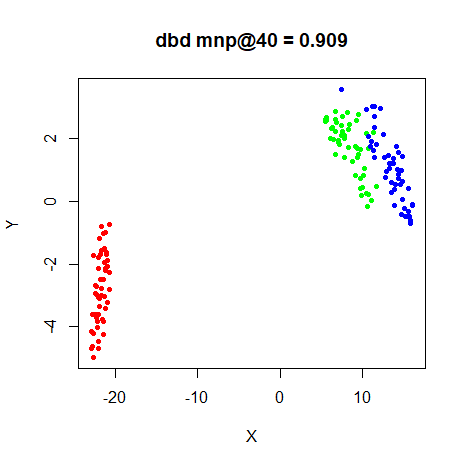

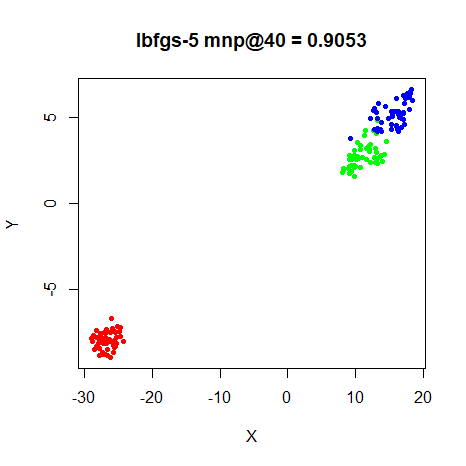

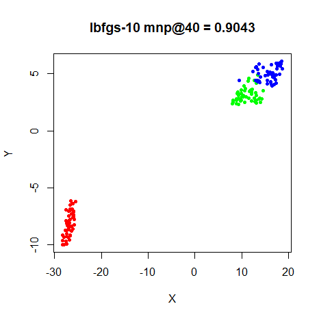

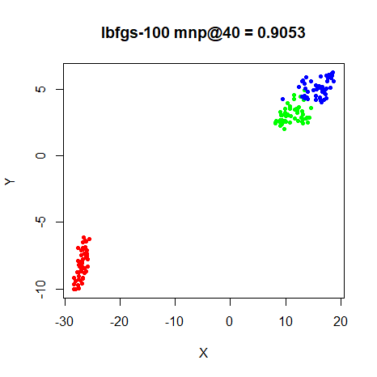

### s1k

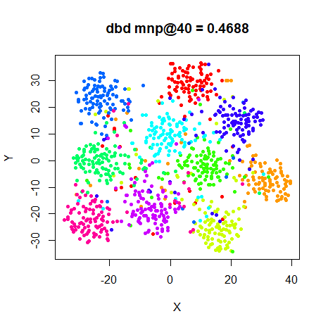

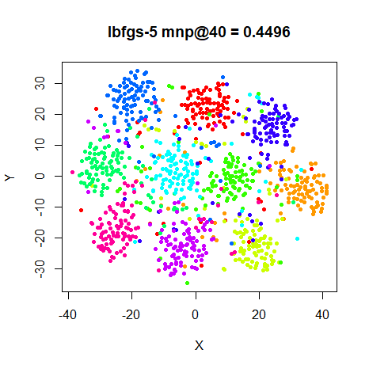

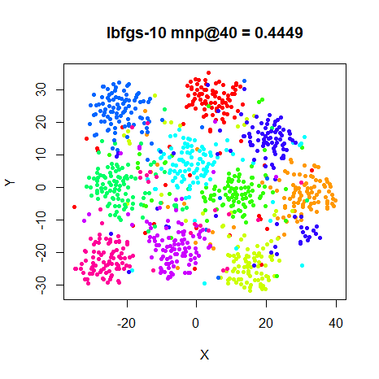

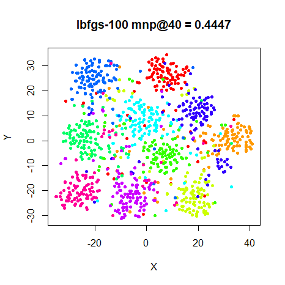

### Olivetti Faces

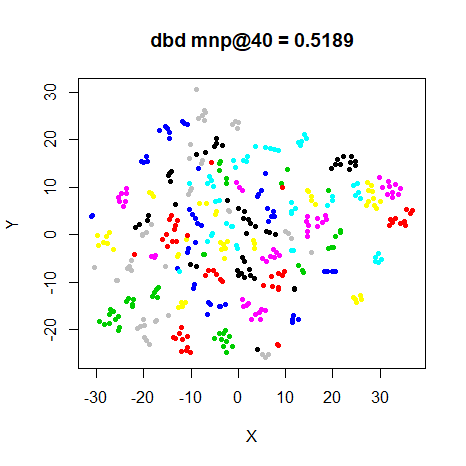

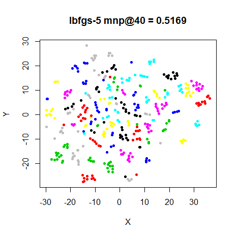

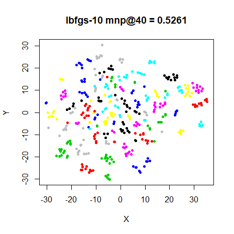

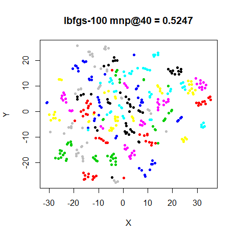

### Frey Faces

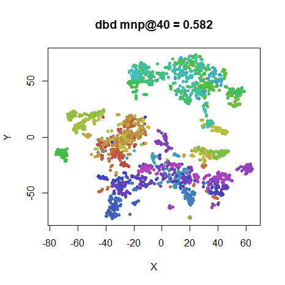

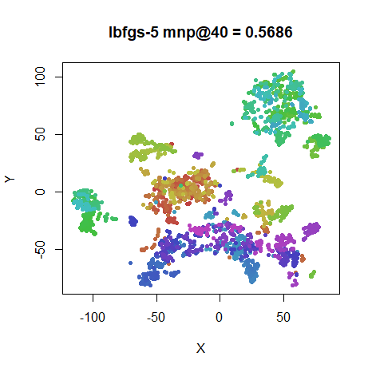

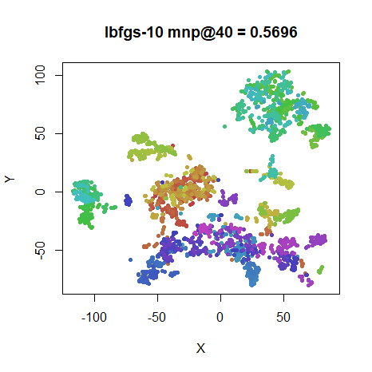

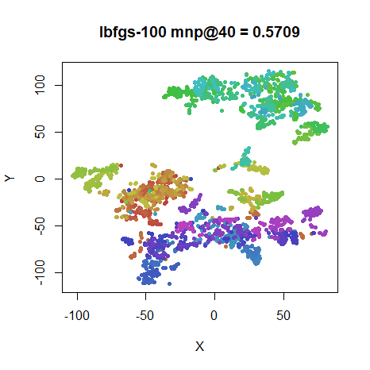

### COIL-20

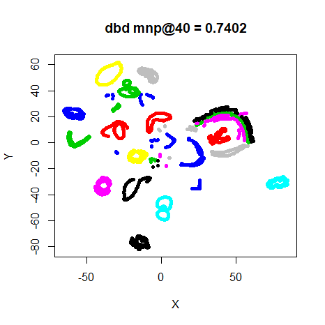

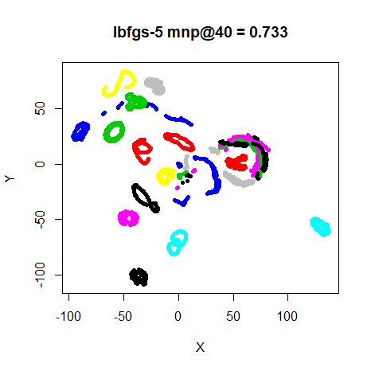

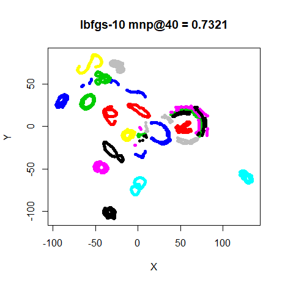

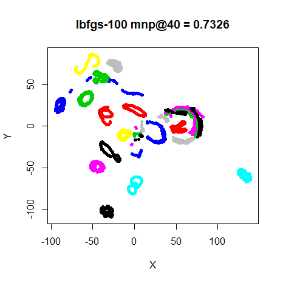

### MNIST (6,000)

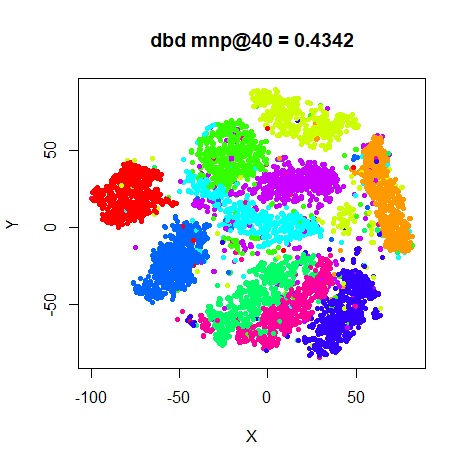

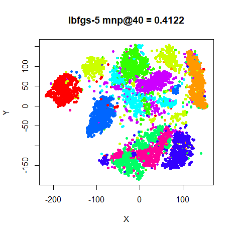

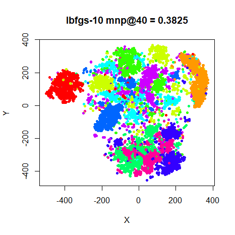

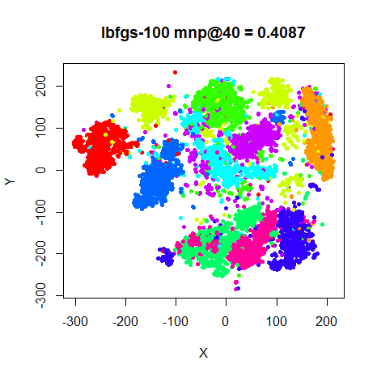

### Fashion (6,000)

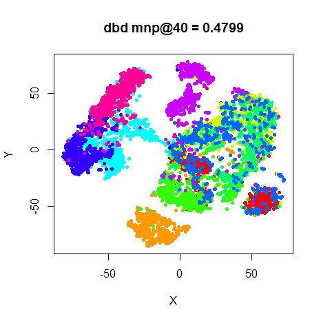

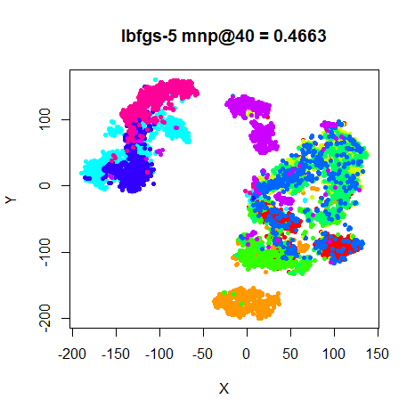

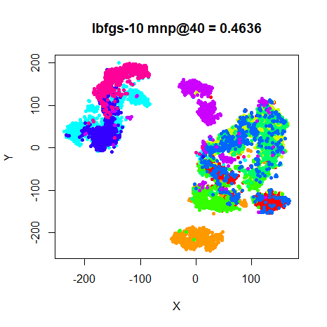

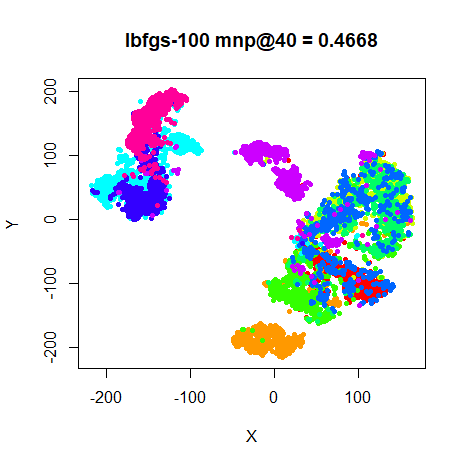

Using L-BFGS seems fine for the most part, until you get to the MNIST digits. Those are some ugly looking plots, but they are minima. Looking at the size of the steps that DBD takes versus L-BFGS during the optimization, L-BFGS will take much larger steps than DBD. Given the highly non-linear nature of the t-SNE cost function, the usual line search settings used in L-BFGS may be inappropriate.